# Tree splitting rules

Joshua Loftus

## Sorting preliminaries

Check the documentation for `?sort` and `?order` and then write code to output the values of `Y` sorted according to the order of `X`

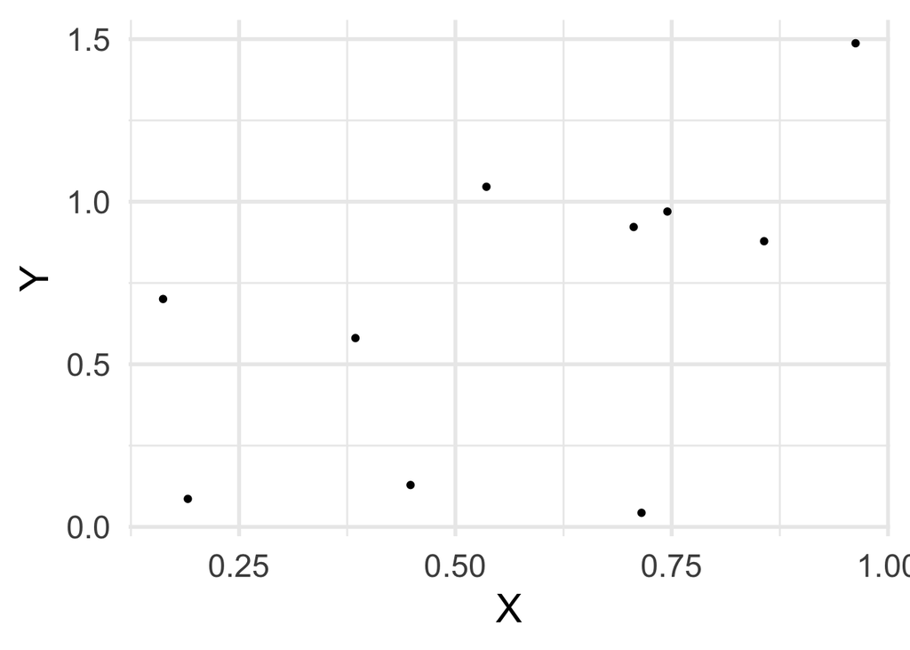

```r
X <- runif(10)
Y <- X + rnorm(10)
qplot(X, Y)
```

Base R solution

```r
Y[order(X)]
```

```
##  [1] 0.70076257 0.08613248 0.58063740 0.12880954 1.04591264 0.92221713
##  [7] 0.04330536 0.96979525 0.87850142 1.48724097
```

#### Check with tidyverse solution

```r
egdf <- data.frame(X = X, Y = Y)
egdf %>%
  arrange(X)
```

```
##            X          Y
## 1  0.1621587 0.70076257
## 2  0.1907793 0.08613248
## 3  0.3844635 0.58063740
## 4  0.4481603 0.12880954
## 5  0.5358620 1.04591264
## 6  0.7060425 0.92221713
## 7  0.7151095 0.04330536
## 8  0.7449972 0.96979525
## 9  0.8567907 0.87850142
## 10 0.9625128 1.48724097
```

## Within-leaf averages

Below is some code that computes the average values of `Y` above and below a given split point

Base R

```r
x_split <- 0.5
c(mean(Y[X <= x_split]),
  mean(Y[X > x_split]))
```

```
## [1] 0.3740855 0.8911621
```

tidyverse

```r
egdf %>%
  group_by(X <= x_split) %>%
  summarize(avg_Y = mean(Y))
```

```
## # A tibble: 2 x 2
##   `X <= x_split` avg_Y
##   <lgl>          <dbl>
## 1 FALSE          0.891
## 2 TRUE           0.374
```

#### How much computation is required if we change the value of `x_split`?

Have to re-sort the data to find the indexes of `Y` corresponding to `X` values above/below the new split point

(Sorting a list of `k` items requires–in the worst case–an order of `k*log(k)` operations)

#### Write code that sorts the data on `X` only once, and then, taking each `X` value as a split point consecutively, computes the average `Y` values above and below that split point while minimizing unnecessary computation

```r
x_order <- order(X)
Y_sorted <- Y[x_order]
n <- length(X)
for (i in 1:(n-1)) {
  print(c(mean(Y_sorted[1:i]),
  mean(Y_sorted[(i+1):n])))
}
```

```
## [1] 0.7007626 0.6825058
## [1] 0.3934475 0.7570525
## [1] 0.4558441 0.7822546
## [1] 0.3740855 0.8911621
## [1] 0.5084509 0.8602120
## [1] 0.5774120 0.8447108
## [1] 0.501111 1.111846
## [1] 0.5596965 1.1828712
## [1] 0.5951193 1.4872410
```

#### How can we use this to decide the split point for a regression tree?

We can use the average `Y` values as predictions within each leaf, compute the RSS, and choose the split point giving the lowest RSS

#### How could we change this code to guarantee a minimum number of observations in each leaf?

Instead of making the loop go from 1 to `(n-1)`, we can make it start at `min.obs` and end at `(n - min.obs)`

## Numeric predictor

Write a function that inputs a single numeric predictor and outcome, and outputs a splitting point that achieves the lowest RSS

```r
tree_split <- function(x, y, min.obs = 10) {
  x_order <- order(x)
  X <- x[x_order]
  Y <- y[x_order]
  n <- length(x)
  RSSs <- numeric(length = n-1)
  RSSs[1:length(RSSs)] <- Inf
  for (i in min.obs:(n-min.obs)) {
    Y_left <- Y[1:i]
    Y_right <- Y[(i+1):n]
    RSSs[i] <- sum((Y_left - mean(Y_left))^2) +
      sum((Y_right - mean(Y_right))^2)
  }
  X[which.min(RSSs)]
}
```

### Example data

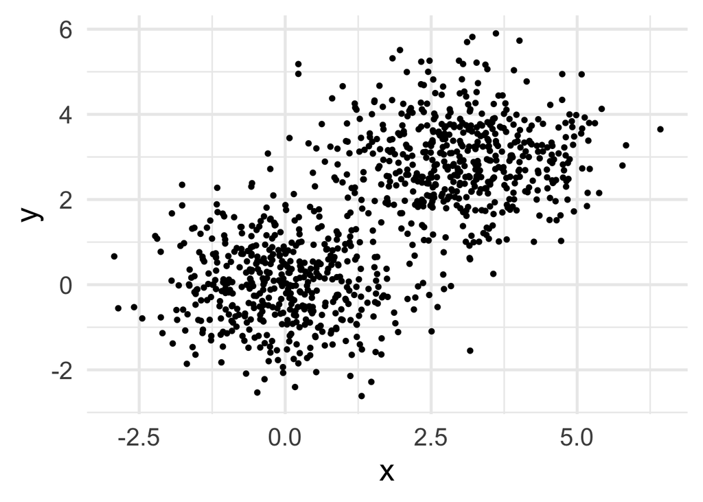

```r
n <- 1000
mixture_ids <- rbinom(n, 1, .5)
x <- rnorm(n) + 3*mixture_ids
y <- rnorm(n) + 3*mixture_ids
qplot(x,y)
```

#### Apply your function to the example data. Try different values of minimum observations per leaf

```r
tree_split(x, y, min.obs = 10)
```

```
## [1] 1.658915
```

#### Change the data generating process to make the example easier/harder and repeat the above initial split

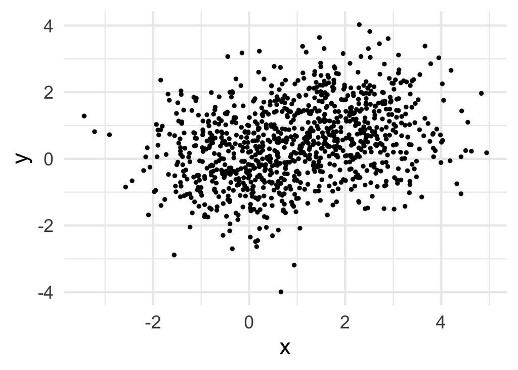

```r
n <- 1000
mixture_ids <- rbinom(n, 1, .5)
x <- rnorm(n) + 2*mixture_ids
y <- rnorm(n) + 1*mixture_ids
qplot(x,y)
```

```r
tree_split(x, y, min.obs = 10)
```

```
## [1] 1.071319
```

#### Compare the initial tree split to a Bayes decision boundary in one of the above examples. Increase `n` and repeat

#### Test the function on some `gapminder` data, plot the initial split point

```r
gm2007 <- gapminder %>% filter(year == 2007)
split2007 <- with(gm2007, tree_split(gdpPercap, lifeExp))
split2007
```

```
## [1] 2280.77
```

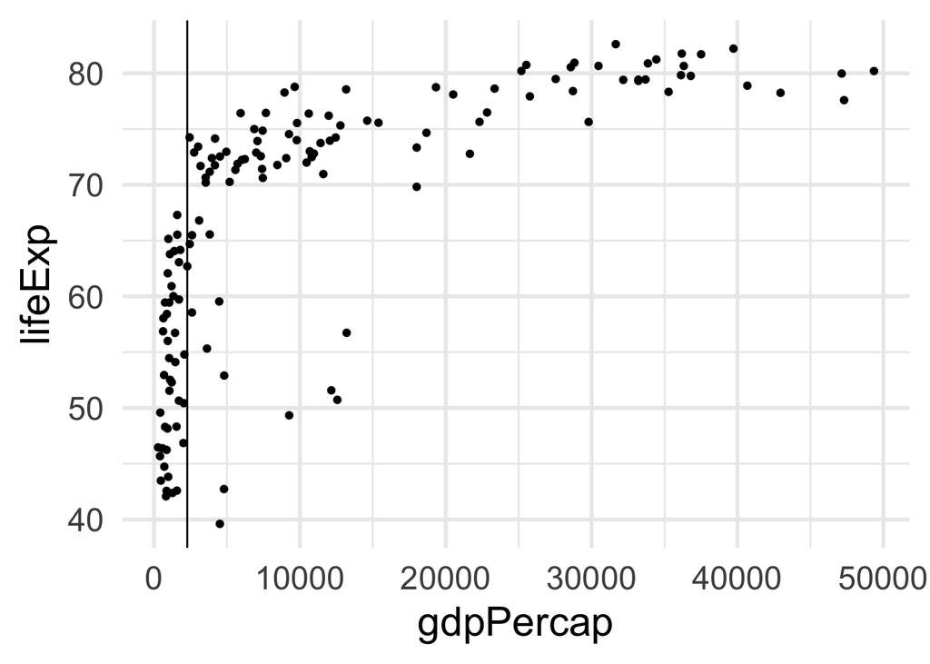

```r
gm2007 %>%
  ggplot(aes(gdpPercap, lifeExp)) +
  geom_point() +
  geom_vline(xintercept = split2007)
```

# Extra practice

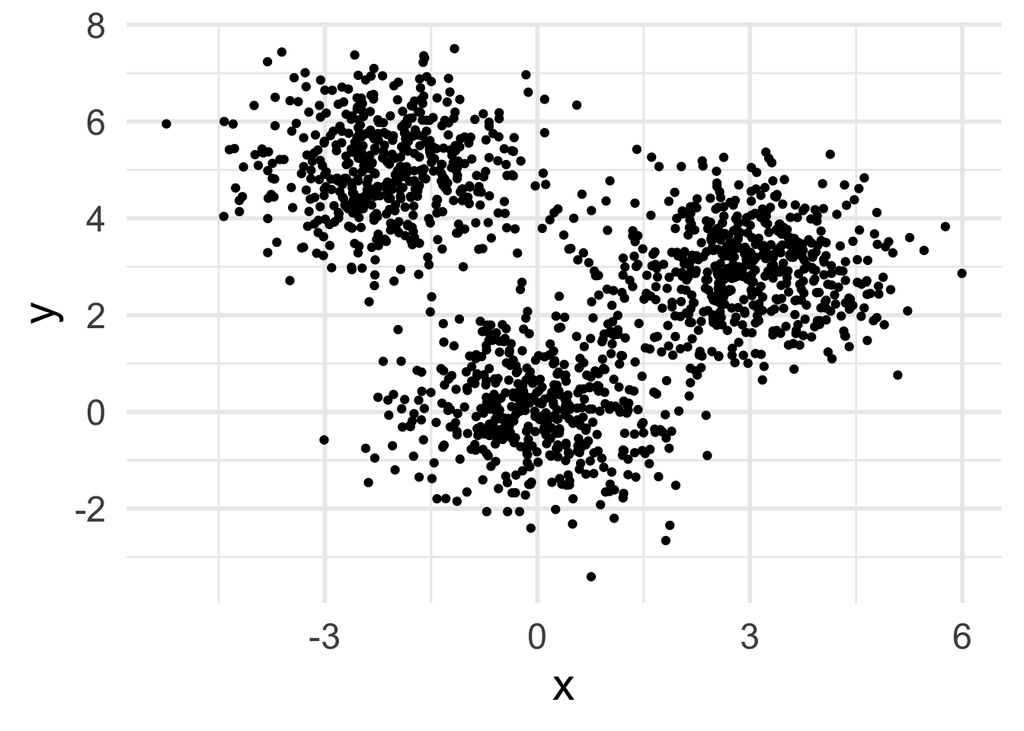

```r
n <- 1000
mixture_ids <- rbinom(n, 1, .5)
x <- rnorm(n) + 3*mixture_ids
y <- rnorm(n) + 3*mixture_ids
x <- c(x, rnorm(n/2, mean = -2))
y <- c(y, rnorm(n/2, mean = 5))
egdf <- data.frame(x = x, y = y)
egplot <- egdf %>%
  ggplot(aes(x, y)) +
  geom_point()
egplot
```

## Multiple splits

#### Use your single split function once, then split the data and apply the function again on each subset

```r
split1 <- tree_split(x, y)
split1
```

```
## [1] -1.026118
```

```r
inds1 <- which(x <= split1)
inds2 <- setdiff(1:length(x), inds1)
```

```r
split2 <- tree_split(x[inds1], y[inds1])
split2
```

```
## [1] -2.30362
```

```r
split3 <- tree_split(x[inds2], y[inds2])
split3
```

```
## [1] 1.894641
```

#### Plot the data and each split point

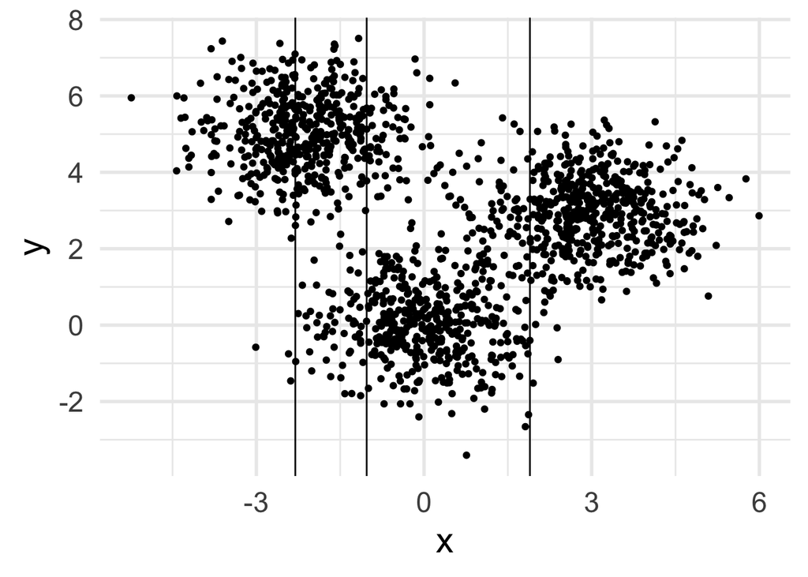

```r
egplot +
  geom_vline(xintercept = split1) +
  geom_vline(xintercept = split2) +
  geom_vline(xintercept = split3)
```

## Recursive splits

#### Write a function taking data and a maximum number of splits as inputs, and outputting a decision tree

#### How does computation scale in number of levels (tree depth)?

## Categorical predictors

#### Write a function for when the outcome variable is categorical and some splitting rule based on e.g. Gini index or entropy